# Homework 3

Emirhan Bugday

November 19, 2018

## TASK 1

### Task 1 - A

3D plots of the gestures are below (plot3D package is used to draw 3D plots of the instances, which represents 3D image in 2D).

#### Gesture 1

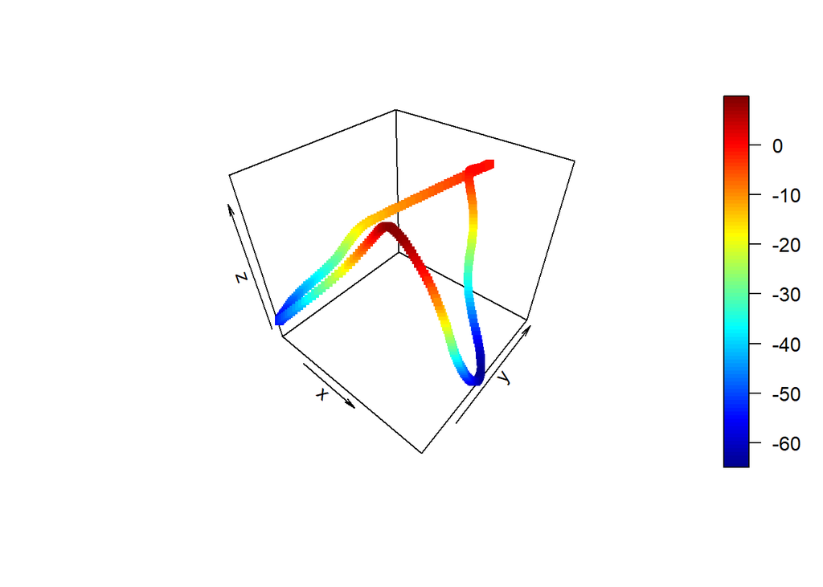

#### Gesture 2

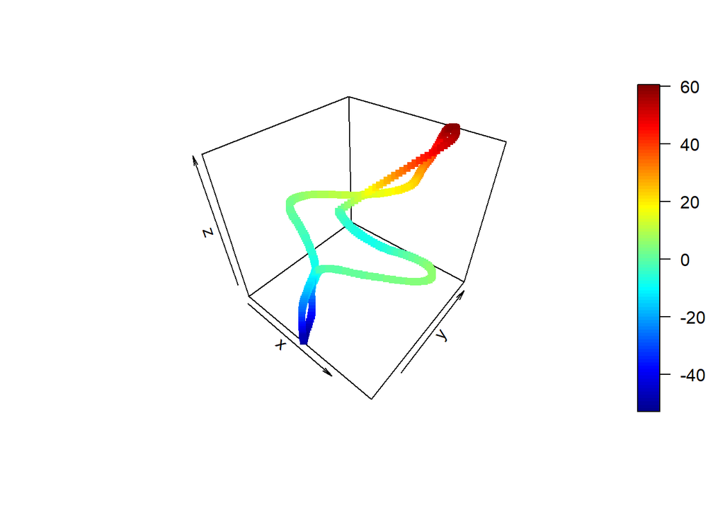

#### Gesture 3

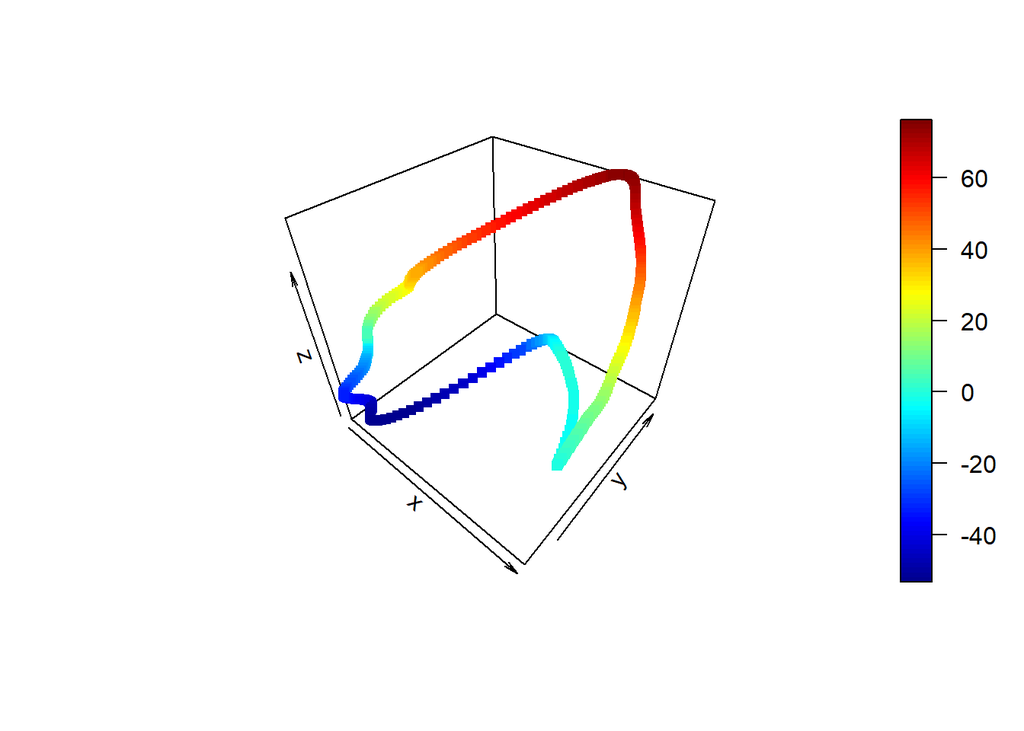

#### Gesture 4

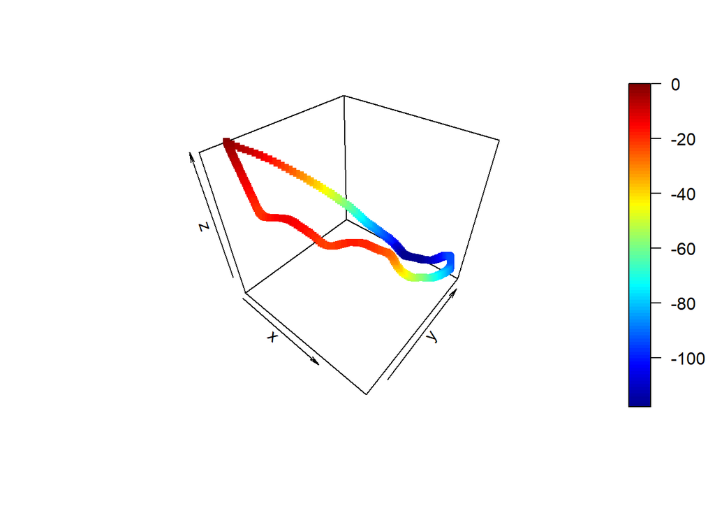

#### Gesture 5

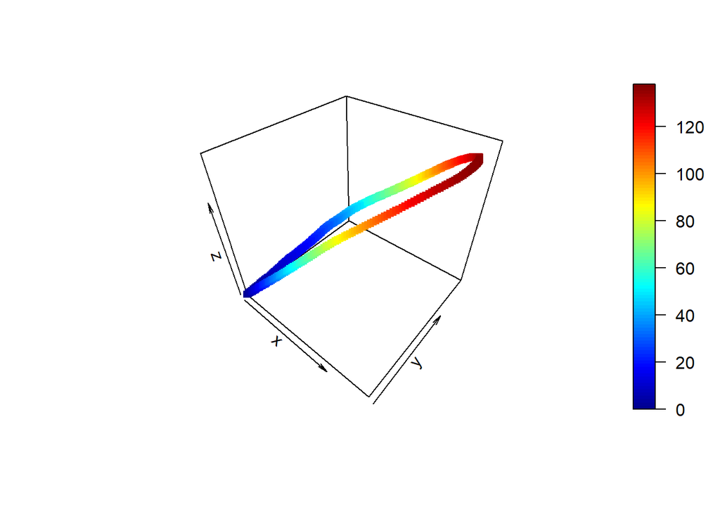

#### Gesture 6

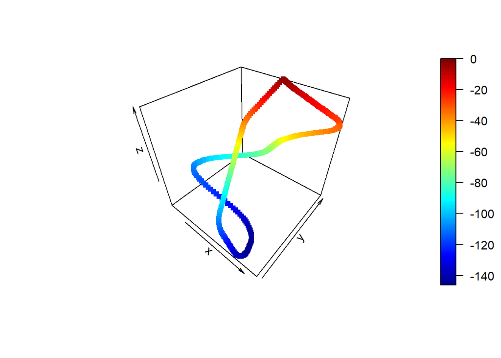

#### Gesture 7

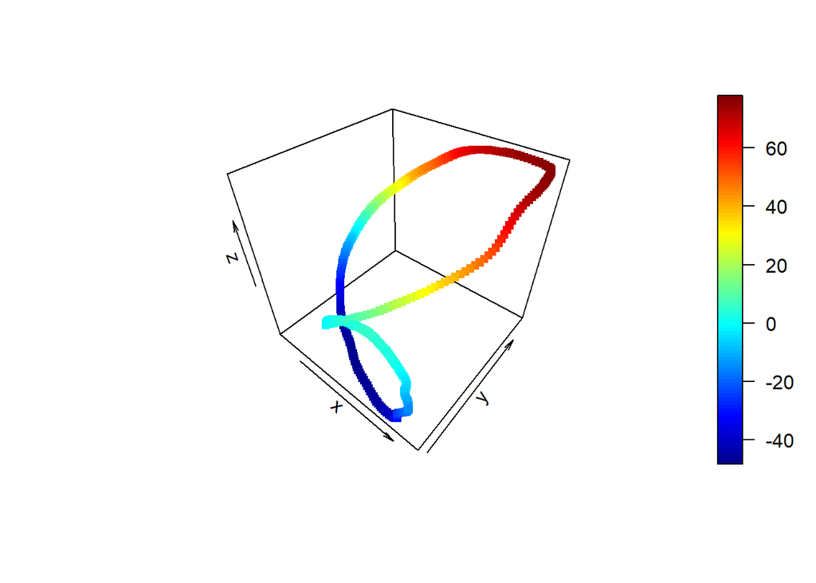

#### Gesture 8

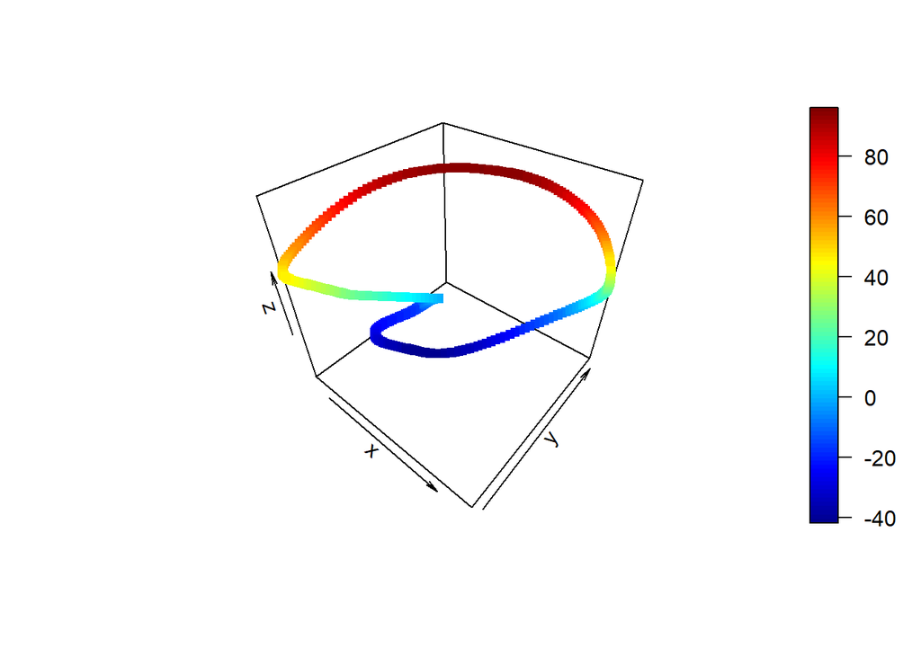

### Task 1 - B

As a result, “manhattan” distance with k = 1 provided has the best performance. More detailed output of the experiment is brovided below.

```
## k-Nearest Neighbors
##
## 896 samples
## 945 predictors
##   8 classes: '1', '2', '3', '4', '5', '6', '7', '8'
##
## No pre-processing
## Resampling: Cross-Validated (10 fold, repeated 1 times)
## Summary of sample sizes: 806, 806, 805, 806, 806, 808, ...
## Resampling results across tuning parameters:
##
##   kmax  distance  Accuracy   Kappa
##   1     1         0.9598349  0.9540491
##   1     2         0.9442405  0.9362016
##   3     1         0.9576127  0.9514950
##   3     2         0.9454268  0.9375424
##   5     1         0.9576127  0.9514950
##   5     2         0.9443157  0.9362698
##   8     1         0.9576127  0.9514950
##   8     2         0.9443157  0.9362698
##
## Tuning parameter 'kernel' was held constant at a value of rectangular
## Accuracy was used to select the optimal model using the largest value.
## The final values used for the model were kmax = 1, distance = 1 and
##  kernel = rectangular.
```

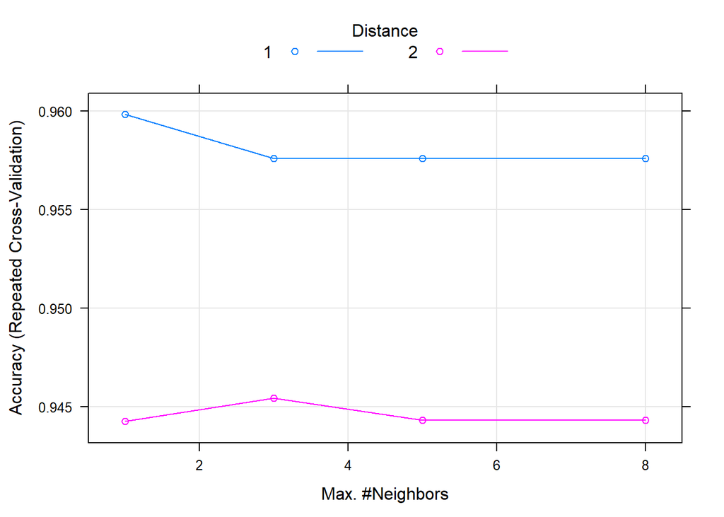

### Task 1 - C

**For “Manhattan” Distance with k = 1:**

Accuracy = 95.4%

Computation Time = 41.75 sec

& Confusion Matrix is as follows

```
##           actual
## prediction   1   2   3   4   5   6   7   8
##          1 430   1   2   3   3   3   0   0
##          2   0 451   0   0   0   0   0   0
##          3   0   0 418   0   9   5   2   0
##          4   2   0   0 392   5  13   0   3
##          5   0   0  16  40 415  16   0   1
##          6   5   0  14  11   1 411   0   0
##          7   0   0   4   0   0   0 445   0
##          8   0   0   0   4   0   1   0 456
```

**For “Euclidean” Distance with k = 3:**

Accuracy = 94.4%

Computation Time = 4.88 sec

& Confusion Matrix is as follows

```
##           actual
## prediction   1   2   3   4   5   6   7   8
##          1 430   1   1   6   3   5   0   0
##          2   0 449   0   0   0   0   0   0
##          3   0   0 413   0   5   6   1   0
##          4   2   0   0 370   1  15   0   1
##          5   0   0  15  60 423  28   0   1
##          6   4   0  21   7   1 394   0   0
##          7   1   2   4   0   0   1 446   0
##          8   0   0   0   7   0   0   0 458
```

## TASK 2

### Task 2 - A, B

Logistic regression model with fusel lasso penalty is trained on the training data, via “penalized” package.

lambda between 0 and 2 is tested for L1 penaltization on the differences of the coefficients while L1 penalization on the coefficients is set to 1 with 2 fold cross validation (2 fold is used due to computational costs)

Best lambda is found as 0.31 & 23 features are selected among 96. Summary of the result is provided below.

```
## $lambda
## [1] 0.3168442
##
## $cvl
## [1] -42.87398
##
## $predictions
##   [1] 0.14331893 0.78717108 0.19297002 0.55293367 0.97007549 0.96085056
##   [7] 0.10268309 0.88873396 0.94143243 0.85749670 0.55431175 0.43345556
##  [13] 0.44147761 0.96535803 0.06067441 0.92732090 0.97550296 0.97508352
##  [19] 0.59979859 0.31730092 0.80975339 0.67069977 0.93637613 0.45857255
##  [25] 0.92307727 0.23919247 0.91113498 0.07544438 0.88622820 0.97093978
##  [31] 0.99018679 0.98072958 0.91152439 0.98070157 0.96262361 0.03002144
##  [37] 0.58272200 0.96861064 0.37419357 0.98083855 0.56490357 0.51052595
##  [43] 0.97605930 0.09750449 0.49659728 0.97311671 0.84480873 0.42409505
##  [49] 0.91818086 0.27320597 0.90725810 0.92308618 0.81786828 0.91168927
##  [55] 0.92166626 0.93020284 0.34230218 0.15202855 0.84832713 0.96360484
##  [61] 0.98440409 0.45218176 0.08189055 0.97928460 0.85548920 0.24238691
##  [67] 0.90412548 0.87821000 0.97221422 0.94673675 0.25145061 0.97148047
##  [73] 0.62123359 0.95071679 0.95103072 0.92851311 0.98680545 0.97688161
##  [79] 0.93543515 0.27745877 0.82508548 0.26094284 0.95407706 0.60467140
##  [85] 0.11035341 0.15002233 0.48009420 0.96633556 0.88605511 0.93989354
##  [91] 0.06797938 0.85025194 0.94034023 0.86411379 0.74251048 0.23721866
##  [97] 0.65734691 0.94372307 0.98352123 0.98007147
##
## $fold
##   1   2   3   4   5   6   7   8   9  10  11  12  13  14  15  16  17  18
##   1   2   1   1   2   2   2   2   1   1   1   1   1   2   2   1   2   2
##  19  20  21  22  23  24  25  26  27  28  29  30  31  32  33  34  35  36
##   2   2   1   1   1   1   1   2   1   2   1   1   2   1   2   2   2   2
##  37  38  39  40  41  42  43  44  45  46  47  48  49  50  51  52  53  54
##   2   2   2   2   2   2   2   1   1   2   1   1   1   2   1   2   2   2
##  55  56  57  58  59  60  61  62  63  64  65  66  67  68  69  70  71  72
##   1   1   1   2   1   1   1   1   2   2   1   1   1   1   2   1   1   1
##  73  74  75  76  77  78  79  80  81  82  83  84  85  86  87  88  89  90
##   2   1   1   1   1   2   2   1   2   2   2   1   2   2   1   2   1   1
##  91  92  93  94  95  96  97  98  99 100
##   2   1   2   2   1   2   1   2   2   2
##
## $fullfit
## Penalized logistic regression object
## 96 regression coefficients of which 23 are non-zero
##
## Loglikelihood =   -22.93766
## L1 penalty =  7.164469   at lambda1 =  1
## L2 penalty =  1.771895   at lambda2 =  0.3168442
```

**Accuracy** of the model on the test data is **82%** and

**Confusion Matrix** is the following:

```
##           actual
## prediction  0  1
##          0 25  7
##          1 11 57
```

Then, L1 penalization on the coefficients are optimized while lamda set for 0.31 for L1 penaltization on the differences of the coefficients. Results are provided below.

```
## $lambda
## [1] 0.9564359
##
## $cvl
## [1] -30.83956
##
## $predictions
##   [1] 0.20757284 0.89454164 0.37355139 0.17924462 0.88789890 0.90411248
##   [7] 0.20534132 0.86892503 0.95402377 0.87957935 0.69085793 0.74412253
##  [13] 0.35992960 0.98102676 0.07570621 0.88674461 0.97134285 0.97648785
##  [19] 0.21790390 0.18046646 0.92305654 0.79207562 0.97279633 0.10887542
##  [25] 0.96961784 0.37646008 0.91203294 0.06647113 0.95792552 0.96022408
##  [31] 0.96080814 0.96815859 0.90548449 0.95011170 0.97571355 0.05905785
##  [37] 0.93320996 0.96941952 0.14013507 0.96107408 0.52627071 0.94255928
##  [43] 0.92843035 0.13276750 0.33190161 0.98013068 0.79480772 0.05785950
##  [49] 0.95508198 0.28991072 0.84317833 0.94969655 0.80517853 0.29468607
##  [55] 0.95162596 0.94906679 0.04858939 0.08776444 0.94104500 0.95766912
##  [61] 0.98035813 0.31778387 0.23556167 0.96556742 0.93698145 0.20004278
##  [67] 0.92046595 0.90650705 0.94268447 0.94152322 0.38016515 0.97674301
##  [73] 0.97300880 0.95423674 0.97393214 0.91948977 0.97899190 0.95981555
##  [79] 0.96868903 0.45205788 0.66184031 0.62187233 0.95738044 0.43937695
##  [85] 0.08552474 0.23147095 0.12092086 0.96484135 0.69177171 0.91510858
##  [91] 0.03715918 0.90882180 0.96001834 0.39247057 0.70551085 0.32951017
##  [97] 0.33863485 0.87795926 0.94461287 0.97809557
##
## $fold
##   1   2   3   4   5   6   7   8   9  10  11  12  13  14  15  16  17  18
##   2   2   1   1   2   2   2   1   1   2   2   1   2   2   1   1   2   1
##  19  20  21  22  23  24  25  26  27  28  29  30  31  32  33  34  35  36
##   2   1   2   2   1   1   1   2   2   1   1   2   2   1   2   2   1   2
##  37  38  39  40  41  42  43  44  45  46  47  48  49  50  51  52  53  54
##   2   2   1   1   2   2   2   2   1   1   2   1   2   1   1   2   1   2
##  55  56  57  58  59  60  61  62  63  64  65  66  67  68  69  70  71  72
##   2   2   2   1   1   1   2   2   1   1   1   2   1   2   1   1   2   1
##  73  74  75  76  77  78  79  80  81  82  83  84  85  86  87  88  89  90
##   2   2   2   2   1   2   1   1   1   1   1   1   1   2   2   1   2   2
##  91  92  93  94  95  96  97  98  99 100
##   1   2   1   2   1   1   2   1   1   1
##
## $fullfit
## Penalized logistic regression object
## 96 regression coefficients of which 24 are non-zero
##
## Loglikelihood =   -22.76584
## L1 penalty =  6.988731   at lambda1 =  0.9564359
## L2 penalty =  1.804256   at lambda2 =  0.3168442
```

However, accuracy remained at **82%** and confusion matrix is stayed as the same.

### Task 2 - C, D

After the described time series transformation is applied, Logistic regression model with fusel lasso penalty is trained on the training data, via “penalized” package.

lambda between 0 and 2 is tested for L1 penaltization on the differences of the coefficients while L1 penalization on the coefficients is set to 1 with 2 fold cross validation (2 fold is used due to computational costs)

Best lambda is found as 0.19 & 18 features are selected among 95. Summary of the result is provided below.

```
## $lambda
## [1] 0.1931916
##
## $cvl
## [1] -45.08289
##
## $predictions
##   [1] 0.3392881 0.8179800 0.3398504 0.7068026 0.9613235 0.8654524 0.4300836
##   [8] 0.6150713 0.9240078 0.5978900 0.5278056 0.2746751 0.6611161 0.9521731
##  [15] 0.2925167 0.8722667 0.9087896 0.9455074 0.5800490 0.6292600 0.4805135
##  [22] 0.7609577 0.9341765 0.7757978 0.9647997 0.5936112 0.8631703 0.6023691
##  [29] 0.6163064 0.9221891 0.9235267 0.9366505 0.7623452 0.9333300 0.9226689
##  [36] 0.6872509 0.8256933 0.8752958 0.5851720 0.9331891 0.5891327 0.5751566
##  [43] 0.9072694 0.3347177 0.8288319 0.9364882 0.9434174 0.6081866 0.9758810
##  [50] 0.5570083 0.8675166 0.7256304 0.7701476 0.3494629 0.8671483 0.8815178
##  [57] 0.2941129 0.1644301 0.8479318 0.8887584 0.9516678 0.7832269 0.2717799
##  [64] 0.9352866 0.9495280 0.8225560 0.8691736 0.7031579 0.9594099 0.8880253
##  [71] 0.4294438 0.9662222 0.8198303 0.9321229 0.9667643 0.8919812 0.9394304
##  [78] 0.9445789 0.9211847 0.6920560 0.5458498 0.3953456 0.9511344 0.3905523
##  [85] 0.2429186 0.4382272 0.4889389 0.9443259 0.4720267 0.9356971 0.2128994
##  [92] 0.7664818 0.7610357 0.5559896 0.8099517 0.2710571 0.4384752 0.5955680
##  [99] 0.9197325 0.8853801
##
## $fold
##   1   2   3   4   5   6   7   8   9  10  11  12  13  14  15  16  17  18
##   1   1   1   2   1   1   2   1   1   2   1   2   2   2   2   1   2   2
##  19  20  21  22  23  24  25  26  27  28  29  30  31  32  33  34  35  36
##   1   1   2   2   2   1   1   1   1   1   2   1   2   2   2   2   1   1
##  37  38  39  40  41  42  43  44  45  46  47  48  49  50  51  52  53  54
##   1   2   2   2   1   1   1   2   1   2   1   2   1   1   1   1   1   2
##  55  56  57  58  59  60  61  62  63  64  65  66  67  68  69  70  71  72
##   2   2   2   2   2   1   1   1   1   1   1   1   1   2   1   2   2   2
##  73  74  75  76  77  78  79  80  81  82  83  84  85  86  87  88  89  90
##   1   2   1   2   2   2   1   1   2   2   1   1   2   2   2   2   2   1
##  91  92  93  94  95  96  97  98  99 100
##   2   2   2   1   2   2   1   1   1   2
##
## $fullfit
## Penalized logistic regression object
## 95 regression coefficients of which 18 are non-zero
##
## Loglikelihood =   -28.82217
## L1 penalty =  10.69105   at lambda1 =  1
## L2 penalty =  1.871634   at lambda2 =  0.1931916
```

**Confusion Matrix** is the following:

```
##           actual
## prediction  0  1
##          0 25  7
##          1 11 57
```

Then, L1 penalization on the coefficients are optimized while lamda set for 0.19 for L1 penaltization on the differences of the coefficients. Results are provided below.

```
## $lambda
## [1] 0.2414493
##
## $cvl
## [1] -35.41963
##
## $predictions
##   [1] 0.06676296 0.84672151 0.16474117 0.85958749 0.98065923 0.90948815
##   [7] 0.32057063 0.69456334 0.98417964 0.69198514 0.88443347 0.41118590
##  [13] 0.88573769 0.99681199 0.19685072 0.66886389 0.97233984 0.98626665
##  [19] 0.25696312 0.34167577 0.69184445 0.96873286 0.98758887 0.08205975
##  [25] 0.93281669 0.17283938 0.83140351 0.37135094 0.82171656 0.97837197
##  [31] 0.98411642 0.99265657 0.91403560 0.98898690 0.97029311 0.54195300
##  [37] 0.97553442 0.97646574 0.70089801 0.99542871 0.38311448 0.57464222
##  [43] 0.98491147 0.09314501 0.33381940 0.98922363 0.68481109 0.76754157
##  [49] 0.96866232 0.23191141 0.91372006 0.76966972 0.47940219 0.61797722
##  [55] 0.96188545 0.95111503 0.33321210 0.04760896 0.93341154 0.99085784
##  [61] 0.99470812 0.46945794 0.18949172 0.99451020 0.97090832 0.51695211
##  [67] 0.95290340 0.95525510 0.97096379 0.97710136 0.48014893 0.99396517
##  [73] 0.88794009 0.95794685 0.97786503 0.99403247 0.98847601 0.98952526
##  [79] 0.98712580 0.36106433 0.54925798 0.70911266 0.98844360 0.23382039
##  [85] 0.09971018 0.36837240 0.20919275 0.99339237 0.77777229 0.66792563
##  [91] 0.04353750 0.83382207 0.94796825 0.61944376 0.96152058 0.28839318
##  [97] 0.35882902 0.87454499 0.99014961 0.96116379
##
## $fold
##   1   2   3   4   5   6   7   8   9  10  11  12  13  14  15  16  17  18
##   1   2   1   1   2   2   1   2   2   1   1   2   1   1   2   1   2   1
##  19  20  21  22  23  24  25  26  27  28  29  30  31  32  33  34  35  36
##   2   2   1   2   2   1   1   2   1   1   2   2   1   1   1   2   1   2
##  37  38  39  40  41  42  43  44  45  46  47  48  49  50  51  52  53  54
##   1   1   2   2   2   1   1   1   1   1   1   1   2   2   2   2   1   2
##  55  56  57  58  59  60  61  62  63  64  65  66  67  68  69  70  71  72
##   1   1   2   2   1   1   1   1   2   2   2   1   2   2   2   1   2   2
##  73  74  75  76  77  78  79  80  81  82  83  84  85  86  87  88  89  90
##   2   2   2   2   2   1   1   2   1   2   1   1   2   1   2   2   2   2
##  91  92  93  94  95  96  97  98  99 100
##   1   1   1   2   1   1   2   1   1   2
##
## $fullfit
## Penalized logistic regression object
## 95 regression coefficients of which 33 are non-zero
##
## Loglikelihood =   -18.01638
## L1 penalty =  7.071318   at lambda1 =  0.2414493
## L2 penalty =  3.351988   at lambda2 =  0.1931916
```

As a result Accuracy is increased to **85%** and confusion matrix become as follows:

```
##           actual
## prediction  0  1
##          0 29  8
##          1  7 56
```

## APPENDIX

Source code of Task 1 and Task 2

### TASK 1

```r
# Clear connections, environment
closeAllConnections()
rm(list = ls())
gc()

# Load Neccesary Packages
library(data.table)
library(caret)
library(tictoc)
library(kknn)

# Load Train Data
fname='G:\\My Drive\\Z.ME\\Boun\\IE 582\\HW-3\\UWave\\uWaveGestureLibrary_X_TRAIN' # data path
traindata_x <- as.matrix(read.table(fname))  # read data into a matrix named traindata

fname='G:\\My Drive\\Z.ME\\Boun\\IE 582\\HW-3\\UWave\\uWaveGestureLibrary_Y_TRAIN' # data path
traindata_y <- as.matrix(read.table(fname))  # read data into a matrix named traindata

fname='G:\\My Drive\\Z.ME\\Boun\\IE 582\\HW-3\\UWave\\uWaveGestureLibrary_Z_TRAIN' # data path
traindata_z <- as.matrix(read.table(fname))  # read data into a matrix named traindata

# Cbind Train Data and Change Column Names
traindata <- cbind(traindata_x, traindata_y[,-1])
traindata <- cbind(traindata, traindata_z[,-1])
traindata<- as.data.table(traindata)
names(traindata) <- as.character(c("gesture", 1:(dim(traindata)[2] - 1)))
# names(traindata) <- as.character(c("gesture", paste0("V", 1:(dim(traindata)[2] - 1))))
str(traindata)

# Load Test Data
fname='G:\\My Drive\\Z.ME\\Boun\\IE 582\\HW-3\\UWave\\uWaveGestureLibrary_X_TEST' # data path
testdata_x <- as.matrix(read.table(fname))  # read data into a matrix named traindata

fname='G:\\My Drive\\Z.ME\\Boun\\IE 582\\HW-3\\UWave\\uWaveGestureLibrary_Y_TEST' # data path
testdata_y <- as.matrix(read.table(fname))  # read data into a matrix named traindata

fname='G:\\My Drive\\Z.ME\\Boun\\IE 582\\HW-3\\UWave\\uWaveGestureLibrary_Z_TEST' # data path
testdata_z <- as.matrix(read.table(fname))  # read data into a matrix named traindata

testdata <- cbind(testdata_x, testdata_y[,-1])
testdata <- cbind(testdata, testdata_z[,-1])
testdata<- as.data.table(testdata)
names(testdata) <- as.character(c("gesture", 1:(dim(testdata)[2] - 1)))
# names(testdata) <- as.character(c("gesture", paste0("V", 1:(dim(testdata)[2] - 1))))
str(testdata)


#1-A
i <- 1
instance <- data.table(Label = traindata_x[i,1], X_a = traindata_x[i,-1], Y_a = traindata_y[i,-1], Z_a = traindata_z[i,-1])

# Calculate Position from accerelation
instance[, X := cumsum(X_a)]
instance[, Y := cumsum(Y_a)]
instance[, Z := cumsum(Z_a)]

par(mfrow=c(1,1))

library("plot3D")
points3D(x = instance$X, y = instance$Y, z = instance$Z, pch=".", cex=7)

# library(rgl)
# plot3d(x = instance$X, y = instance$Y, z = instance$Z, pch=".", cex=7)
# plot3d(x = instance$X, y = instance$Y, z = instance$time, pch=".", cex=7)


#1-B
# For Classification
traindata[, gesture := as.factor(gesture)]
testdata[, gesture := as.factor(gesture)]

# Create 10 fold CV data set
fitControl <- trainControl(## 10-fold CV
  method = "repeatedcv",
  number = 10,
  ## repeated ten times
  repeats = 1)

# Create Parameter grid to evaluate throught cross validation
# Selected Distances: 1 - Manhattan, 2 - Euclidean
# Tries k values: 1,3,5
# kernel = "rectangular" corresponds standard unweighted knn (it is required for the package)
knnGrid <-  expand.grid(kmax = c(1,3,5,8), distance = c(1,2), kernel = "rectangular")

# Optimize parameters using the train data set
knnFit <- train(gesture ~ ., data = traindata,
                method = "kknn",
                trControl = fitControl,
                tuneGrid = knnGrid,
                verbose = TRUE)

saveRDS(knnFit, "G:\\My Drive\\Z.ME\\Boun\\IE 582\\HW-3\\KnnFitQ1Final.Rds")

# Plot the Result
plot(knnFit)

# Print Details
print(knnFit)


# 1-C

tic("manhattan")
prediction1 <-  kknn(gesture ~ .,
                     traindata,
                     testdata,
                     k = 1,
                     distance = 1,
                     kernel = "rectangular",
                     # na.action = na.omit(),
                     scale = FALSE)
toc()

result1 <- cbind(data.table(prediction = prediction1$fitted.values), data.table(actual = testdata$gesture))
cm1 <- table(result1)
accu1 <- sum(diag(cm1))/sum(cm1)

tic("euclidean")
prediction2 <-  kknn(gesture ~ .,
                     traindata,
                     testdata,
                     k = 3,
                     distance = 2,
                     kernel = "rectangular",
                     # na.action = na.omit(),
                     scale = FALSE)
toc()

result2 <- cbind(data.table(prediction = prediction2$fitted.values), data.table(actual = testdata$gesture))
cm2 <- table(result2)
accu2 <- sum(diag(cm2))/sum(cm2)


save.image(file = "G:\\My Drive\\Z.ME\\Boun\\IE 582\\HW-3\\Q1-Final.RData")
```

### TASK 2

```r
# Clear connections, environment
closeAllConnections()
rm(list = ls())
gc()

library(penalized)
library(data.table)

# Load Train Data
fname='G:\\My Drive\\Z.ME\\Boun\\IE 582\\HW-3\\NN_Classification\\ecgTRAIN' # data path
traindata <- as.data.table(read.table(fname))  # read data into a matrix named traindata

# Train Class Variable
trainclass = traindata[, 1] # takes -1 and 1
# Convert class variable to 0-1
trainclass <- (trainclass + 1) / 2
str(trainclass)
# Train Features
traindata = traindata[, 2:ncol(traindata)]

# Load Test Data
fname='G:\\My Drive\\Z.ME\\Boun\\IE 582\\HW-3\\NN_Classification\\ecgTEST' # data path
testdata <- as.matrix(read.table(fname))  # read data into a matrix named traindata

# Test Class Variable
testclass = testdata[, 1]
# Convert class variable to 0-1
testclass <- (testclass + 1) / 2
# Test Features
testdata=testdata[, 2:ncol(testdata)]


#4-A,B
fusedLasso <- optL2(response = as.matrix(trainclass),
                    penalized = traindata,
                    unpenalized = ~ 0,
                    data = traindata,
                    fusedl = T,
                    standardize = T,
                    lambda1 = 1,
                    minlambda2 = 0,
                    maxlambda2 = 2,
                    fold = 2,
                    model = "logistic")


# pen <- penalized(response = as.matrix(trainclass),
#                  penalized = traindata,
#                  unpenalized = ~ 0,
#                  data = traindata,
#                  fusedl = T,
#                  standardize = F,
#                  lambda1 = 1,
#                  lambda2 = fusedLasso$lambda,
#                  model = "logistic",
#                  trace = T)

coef(fusedLasso$fullfit)

T2_prediction <- predict(object =  fusedLasso$fullfit, as.matrix(testdata))

T2_result <- cbind(data.table(prediction = round(T2_prediction, digit = 0)), data.table(actual = testclass))
T2_cm <- table(T2_result)
T2_accu <- sum(diag(T2_cm))/sum(T2_cm)


fusedLasso_2 <- optL1(response = as.matrix(trainclass),
                    penalized = traindata,
                    unpenalized = ~ 0,
                    data = traindata,
                    fusedl = T,
                    standardize = T,
                    lambda2 = fusedLasso$lambda,
                    minlambda1 = 0,
                    maxlambda1 = 2,
                    fold = 2,
                    model = "logistic")

coef(fusedLasso_2$fullfit)

T2_prediction_2 <- predict(object =  fusedLasso_2$fullfit, as.matrix(testdata))

T2_result_2 <- cbind(data.table(prediction = round(T2_prediction_2, digit = 0)), data.table(actual = testclass))
T2_cm_2 <- table(T2_result_2)
T2_accu_2 <- sum(diag(T2_cm_2))/sum(T2_cm_2)


# 4-C,D

# Compute diff variables for train data
traindata_2 <- as.data.table(traindata)
traindata_2[,instance := c(1:.N)]
traindata_2_2 <- melt(traindata_2,id.vars = "instance")
traindata_2_2 <- traindata_2_2[order(instance, variable)]
traindata_2_2[, value2 := value - shift(value, n = 1, type = "lag"), instance]
traindata_2 <- dcast(traindata_2_2[!is.na(value2), .(instance, variable, value2)], formula = instance  ~ variable, value.var = "value2")
traindata_2[, instance := NULL]

summary(traindata_2)

# Compute diff variables for test data
testdata_2 <- as.data.table(testdata)
testdata_2[,instance := c(1:.N)]
testdata_2_2 <- melt(testdata_2,id.vars = "instance")
testdata_2_2 <- testdata_2_2[order(instance, variable)]
testdata_2_2[, value2 := value - shift(value, n = 1, type = "lag"), instance]
testdata_2 <- dcast(testdata_2_2[!is.na(value2), .(instance, variable, value2)], formula = instance  ~ variable, value.var = "value2")
testdata_2[, instance := NULL]

summary(testdata_2)


fusedLasso2 <- optL2(response = as.matrix(trainclass),
                    penalized = traindata_2,
                    unpenalized = ~ 0,
                    data = traindata_2,
                    fusedl = T,
                    standardize = T,
                    lambda1 = 1,
                    minlambda2 = 0,
                    maxlambda2 = 2,
                    fold = 2,
                    model = "logistic")



coef(fusedLasso2$fullfit)

T2_prediction2 <- predict(object = fusedLasso2$fullfit, as.matrix(testdata_2))

T2_result2 <- cbind(data.table(prediction = round(T2_prediction2, digit = 0)), data.table(actual = testclass))
T2_cm2 <- table(T2_result2)
T2_accu2 <- sum(diag(T2_cm2))/sum(T2_cm2)

fusedLasso2$lambda



fusedLasso2_2 <- optL1(response = as.matrix(trainclass),
                       penalized = traindata_2,
                       unpenalized = ~ 0,
                       data = traindata_2,
                       fusedl = T,
                       standardize = T,
                       lambda2 = fusedLasso2$lambda,
                       minlambda1 = 0,
                       maxlambda1 = 2,
                       fold = 2,
                       model = "logistic")

T2_prediction2_2 <- predict(object = fusedLasso2_2$fullfit, as.matrix(testdata_2))

T2_result2_2 <- cbind(data.table(prediction = round(T2_prediction2_2, digit = 0)), data.table(actual = testclass))
T2_cm2_2 <- table(T2_result2_2)
T2_accu2_2 <- sum(diag(T2_cm2_2))/sum(T2_cm2_2)

save.image(file = "G:\\My Drive\\Z.ME\\Boun\\IE 582\\HW-3\\Q2-Final.RData")
```